# TP: statistiques bayésiennes

**Important:** Ceci est un document R notebook. En cliquant sur knit vous aurez le choix entre un document html, pdf ou word. Le TP doit être rendu sous la forme d’un fichier NOM_prenom_Bayes.html. Il est à remettre dans moodle. CTRL+Alt+i permet d’ouvrir une cellule de code compilable.

# 1 Tests Bayésiens

## 1.1 Echantillon de Bernoulli

Cette partie a pour but d’étudier les erreurs de type I de plusieurs tests, dans le cas standard d’une comparaison d’efficacité d’un nouvel agent avec un médicament de référence. On suppose que l’efficacité du médicament de référence est $p_0=0.7$ et les hypothèses antagonistes sont $H_0: p\leq p_0$ et $H_1: p> p_0.$

**1.** La fonction suivante renvoit la moyenne, la p-valeur, et la borne supérieur de l’intervalle de fluctuation sous l’hypothèse $H_0,$ ci-dessus.

```r
test.p = function(p0, vector, conf.level) {
     if (length(vector)==0) { cat("Erreur ! Le vecteur ",substitute(vector),"est vide.\n")}
      else {
      n = length(vector)-sum(is.na(vector))
      moyenne = mean(vector,na.rm=T)
      p_val = 1- pnorm(moyenne, p0, sqrt(p0*(1-p0)/n))
      borne_sup = qnorm(conf.level, p0, sqrt(p0*(1-p0)/n))
      return(list(moyenne=moyenne, p_val=p_val, borne_sup=borne_sup)) }}

x = rbinom(100,1,0.7) ; test.p(p0=0.7,vector=x,conf.level = 0.95)
```

```
## $moyenne
## [1] 0.72
##
## $p_val
## [1] 0.3312603
##
## $borne_sup
## [1] 0.7753767
```

Créér une fonction permettant d’évaluer par simulation numérique le pourcentage d’erreur de type 1 commises. Cette fonction prendra en paramètre d’entrée: `N`, `n` `p0`, `conf.level` où `N` est le nombre de tests simulés, `n` la taille de l’échantillon et `p` la vraie probabilité de succès du nouvel agent.

```r
simu = function(N, n, p0, conf.level){
  count = 0
  for (i in 1:N){
    x = rbinom(n,1,p0) ; x = test.p(p0=p0,vector=x,conf.level = conf.level)
    if (x$p_val < 0.05){
      count = count + 1
    }
  }
  return(count/N)
}

simu(10000, 100, 0.7, conf.level = 0.95)
```

```
## [1] 0.0509
```

On retombe bien sur le alpha théorique de 5%

**2.** Nous allons maintenant effectuer des tests bayésiens. On choisi un a priori conjugué avec les données (loi Beta) et la fonction de perte considérée est la fonction “0-1”:
$$l(\theta,T)=\alpha_0\mathbb{1}_{\{T=1,\theta\in\Theta_0\}}+
\alpha_1\mathbb{1}_{\{T=0,\theta\in\Theta_1\}}.$$
Le tests de Bayes $T$ pour cette fonction de perte et un a priori $\Pi$ est:
$$T(X_1^n)=\mathbb{1}_{\left\lbrace B_n\leq
\dfrac{\alpha_1\Pi(\Theta_1)}{\alpha_0 \Pi\Theta_0}\right\rbrace}
,\,\,\mbox{avec} \quad B_n=\dfrac{\Pi_n(\Theta_0)}{\Pi_n(\Theta_1)}
\dfrac{\Pi(\Theta_1)}{\Pi(\Theta_0)}.$$
Créer une fonction permettant d’effectuer un test bayésien. Cette fonction prendra en paramètre d’entrée: `p0`, `vector`, `a`, `b` (les paramètres de l’apriori), `alpha0`, `alpha1`.

```r
test.bayesien = function(p0, vector, a, b, alpha0, alpha1){
  n1 = sum(vector)
  n0 = length(vector) - n1
  B =  pbeta(p0, n1+a, n0+b) / (1-pbeta(p0, n1+a, n0+b)) * (1-pbeta(p0, a, b)) / pbeta(p0, a, b)
  if (B <= alpha1 / alpha0 * (1-pbeta(p0, a, b)) / pbeta(p0, a, b)){
    test = 1
  }
  else{
    test=0
  }
  return(test)
}

test.bayesien(0.7, rbinom(100, 1, 0.7), 1, 1, 1, 1)
```

```
## [1] 1
```

**3.** Créer une fonction, `err_I_b`, permettant d’étudier l’erreur de type 1 dans le sens fréquentiste (données générées sous une unique loi de paramètre `p`) .

```r
err_I_b = function(N, n, p0, a, b, alpha0, alpha1){
        count = 0
        for (i in 1:N){
          x = rbinom(n,1,p0) ; x = test.bayesien(p0=p0,vector=x,a,b,alpha0,alpha1)
          if (x == 1){
            count = count + 1
          }
        }
        return(count/N)
}
```

**4.** Tester la fonction pour les différentes circonstances suivantes:`n=10, 50, 100` et $\alpha_0/\alpha_1=\Pi([0,p_0])/\Pi(]p_0,1])$ ou $\alpha_0/\alpha_1=19/1.$ On choisira un a prioiri uniforme.

```r
err_I_b(1000, 10, 0.7, 1,1,19,1)
```

```
## [1] 0.028
```

```r
err_I_b(1000, 50, 0.7, 1,1,19,1)
```

```
## [1] 0.034
```

```r
err_I_b(1000, 100, 0.7, 1,1,19,1)
```

```
## [1] 0.048
```

```r
alpha0 = pbeta(0.7, 1,1)
alpha1 = 1-alpha0
err_I_b(1000, 10, 0.7, 1,1,alpha0,alpha1)
```

```
## [1] 0.146
```

```r
err_I_b(1000, 50, 0.7, 1,1,alpha0,alpha1)
```

```
## [1] 0.327
```

```r
err_I_b(1000, 100, 0.7, 1,1,alpha0,alpha1)
```

```
## [1] 0.313
```

## 1.2 Echantillon de loi normale

Les médecins souhaitent qu’un traitement amènent le biomarqueur $b_0$ à se situer en moyenne dans l’intervalle $I=[45,65].$ Chacune des 5 doses testées ont été soumises à 25 patients ; les patients ne sont traités qu’à une dose (125 volontaires). Pour chacune des doses, on souhaite calculer la probabilité que le biomarqueur soit dans l’intervalle. Le modèle bayésien suivant est utilisé:
$$X\mid \theta, \sigma^2\sim\mathcal{N}(\theta,
\sigma^2),$$
avec une loi conjuguée pour les paramètres $\theta$ et $\sigma$ ([conjugate prior](https://en.wikipedia.org/wiki/Conjugate_prior)).

```r
data=read.csv("biomarker_dose.csv")
```

**1.** Dans un premier temps, on suppose la variance connue est identique dans chaque groupe: $\sigma^2=6$. Quelle est la dose la plus adaptée

```r
proba_dose = function(x, sdx){
    mu0=55
    print(sd(x))
    sd0=10
    n = length(x)
    sigma_post = 1/(sd0*sd0) + n/sdx
    sigma_post = 1 / sigma_post
    mean_post = sigma_post * (mu0/(sd0*sd0)+sum(x)/sdx)
    proba=pnorm(65, mean_post, sqrt(sigma_post)) - pnorm(45, mean_post, sqrt(sigma_post))
    #proba=pnorm(65, mean_post, sigma_post)
    return(proba)
  }

for (i in 1:5){
  Xi = data$X[which(data$Dose == i)]
  print(proba_dose(Xi, 6))
}
```

```
## [1] 8.269035
## [1] 0
## [1] 14.32962
## [1] 0
## [1] 10.61856
## [1] 1
## [1] 10.97797
## [1] 1
## [1] 14.47584
## [1] 5.412904e-139
```

**2.** Maintenant, la variance n’est plus connue. Les probabilités sont à évaluer par méthode de Monte Carlo en utilisant comme a priori la loi normale inverse-gamma: $\theta, \sigma^2 \sim \mathcal{N}\Gamma^{-1}(\mu,\lambda, \alpha, \beta).$ Pour générer sous l’a posteriori, on a:
$$x \mid
y, \mu, \lambda\sim \mathcal{N}(\mu, y/\lambda)\quad \text{et }\quad
y\mid \alpha, \beta\sim \Gamma^{-1}(\alpha, \beta) \,\, \Rightarrow \,\,
(x,y) \sim \mathcal{N}\Gamma^{-1}(\mu,\lambda, \alpha,
\beta)$$

```r
library(invgamma)

# on suppose qu'on dispose de la fonction rinvgamma

proba_mu_nig = function(x, N, mu0, nu, alpha, bet){
  n = length(x)
  # calcul des paramètres de l'à posteriori
  mu0_p = (nu*mu0 + sum(x))/(nu+n)
  nu_p = nu + n
  alpha_p = alpha + n/2
  beta_p = bet + 0.5 * ((sd(x)**2) + n*nu * ((mean(x)-mu0)**2) / (nu+n))
  sum = 0
  for (i in 1:N){
    sigma2 = rinvgamma(1, shape=alpha_p, rate=beta_p)
    sdx = sqrt(sigma2)
    mu = rnorm(1, mu0_p, sd = sdx / nu_p)
    sum = sum + pnorm(65, mu, sdx) - pnorm(45, mu, sdx)
  }
  return(sum/N)
}

n=25
# arbitraires
mu0=55
nu=n
alpha=n/2
bet = 500 #arbitraire mais cohérent car 2*bet = sum of squared deviaton => beta ~= n * sigma2 / 2~= 12.5 * 50 ~= 500

for (i in 1:5){
  Xi = data$X[which(data$Dose == i)]
  print(proba_mu_nig(Xi, 1000, mu0, nu, alpha, bet))
}
```

```
## [1] 0.4687551
## [1] 0.5632029
## [1] 0.8862468
## [1] 0.8816079
## [1] 0.4174531
```

Les résultats sont plus réalistes qu’à la question précédente. La probabilité maximale est atteinte pour la 3ème dose, à quasi égalité avec la 4ème, ce qu’on avait déduit précédemment.

**3.** Cette question nécessite d’avoir installer le logiciel `JAGS` et les packages `rjags`, et `r2jags`. Il s’agit d’utiliser ce logiciel pour effectuer la même analyse qu’à la question précédente mais sans forcément utiliser un a priori conjugué.

```r
#install.packages('R2jags')
library(R2jags)
#Le modèle pour JAGS
model1 <- "
model{
for (i in 1:N) {
x[i] ~ dnorm(theta, inv_sigma)
}
theta ~ dnorm(55, 1/10)
inv_sigma ~ dnorm(1/3, 1/10)
}
"

parameters <- c("theta","inv_sigma")

for (i in 1:5){
  x = data$X[which(data$Dose == i)]
  N <- 25

  # Les données
  datum <- list(N=N,x=x)

  # Les paramètres à étudier

  # Compile et estime le modèle conditionnellement aux données
  Mrun1 <- jags(
    data = datum,
    parameters.to.save = parameters,
    model.file = textConnection(model1),
    n.chains = 2, n.iter = 10000,
    n.burnin = 2000
  )
  print(Mrun1)
}
```

```
## module glm loaded
```

```
##
##
## Inference for Bugs model at "4", fit using jags,
##  2 chains, each with 10000 iterations (first 2000 discarded), n.thin = 8
##  n.sims = 2000 iterations saved
##           mu.vect sd.vect    2.5%     25%     50%     75%   97.5%  Rhat n.eff
## inv_sigma   0.011   0.004   0.005   0.008   0.011   0.014   0.021 1.001  2000
## theta      40.729   2.266  36.764  39.124  40.480  42.073  45.830 1.001  2000
## deviance  186.312   6.370 176.911 181.524 185.205 190.164 201.469 1.001  2000
##
## For each parameter, n.eff is a crude measure of effective sample size,
## and Rhat is the potential scale reduction factor (at convergence, Rhat=1).
##
## DIC info (using the rule, pD = var(deviance)/2)
## pD = 20.3 and DIC = 206.6
## DIC is an estimate of expected predictive error (lower deviance is better).
##
##
## Inference for Bugs model at "5", fit using jags,
##  2 chains, each with 10000 iterations (first 2000 discarded), n.thin = 8
##  n.sims = 2000 iterations saved
##           mu.vect sd.vect    2.5%     25%     50%     75%   97.5%  Rhat n.eff
## inv_sigma   0.004   0.001   0.002   0.003   0.004   0.005   0.007 1.001  2000
## theta      47.227   2.541  42.566  45.387  47.139  48.959  52.564 1.003   710
## deviance  211.278   4.003 204.836 208.363 210.817 213.791 220.447 1.003  1700
##
## For each parameter, n.eff is a crude measure of effective sample size,
## and Rhat is the potential scale reduction factor (at convergence, Rhat=1).
##
## DIC info (using the rule, pD = var(deviance)/2)
## pD = 8.0 and DIC = 219.3
## DIC is an estimate of expected predictive error (lower deviance is better).
##
##
## Inference for Bugs model at "6", fit using jags,
##  2 chains, each with 10000 iterations (first 2000 discarded), n.thin = 8
##  n.sims = 2000 iterations saved
##           mu.vect sd.vect    2.5%     25%     50%     75%   97.5%  Rhat n.eff
## inv_sigma   0.009   0.003   0.005   0.007   0.009   0.011   0.015 1.001  2000
## theta      51.126   1.821  47.691  49.914  51.073  52.236  55.080 1.001  2000
```

[output cut: 25 more lines]

```
##
## Inference for Bugs model at "8", fit using jags,
##  2 chains, each with 10000 iterations (first 2000 discarded), n.thin = 8
##  n.sims = 2000 iterations saved
##           mu.vect sd.vect    2.5%     25%     50%     75%   97.5%  Rhat n.eff
## inv_sigma   0.003   0.001   0.001   0.002   0.003   0.004   0.005 1.001  2000
## theta      64.221   3.011  58.006  62.223  64.294  66.310  69.784 1.001  2000
## deviance  220.034   5.354 210.443 216.269 219.849 223.716 231.466 1.001  2000
##
## For each parameter, n.eff is a crude measure of effective sample size,
## and Rhat is the potential scale reduction factor (at convergence, Rhat=1).
##
## DIC info (using the rule, pD = var(deviance)/2)
## pD = 14.3 and DIC = 234.4
## DIC is an estimate of expected predictive error (lower deviance is better).
```

Je ne sais pas si l’analyse est suffisante, et je ne savais pas comment extraire la valeur de theta de l’objet Mrun1.

On peut lire ces résultats de cette manière : le meilleur traitement est celui qui amène la moyenne du biomarqueur le plus proche de 55. Ce sont donc à nouveau le 3ème, légèrement en dessous, et le 4ème.

Pour vous aider, l’exemple suivant est détaillé dans la section qui suit: $\theta\sim \mathcal{N}(0,1)$ et $X_i \sim \mathcal{N}(\theta,1).$

### 1.2.1 JAGS, un premier exemple

Le code ci-dessous permet de construire un model bayésien pour JAGS. L’exemple est très simple pour que vous puissiez vous concentrer sur la structure à donner aux codes: un modèle, des données, des paramètres et la fonction `jags` pour obtenir l’a posteriori.

```r
#install.packages('R2jags')
library(R2jags)
N <- 50
x <-  rnorm(N,2,1) # data

#Le modèle pour JAGS
model1 <- "
model{
for (i in 1:N) {
x[i] ~ dnorm(theta,inv_sigma)
}
theta ~ dexp(1)
inv_sigma = 1/10
}
"

# Les données
datum <- list(N=N,x=x)

# Les paramètres à étudier
parameters <- c("theta","inv_sigma")

# Compile et estime le modèle conditionnellement aux données
Mrun1 <- jags(
  data = datum,
  parameters.to.save = parameters,
  model.file = textConnection(model1),
  n.chains = 2, n.iter = 10000,
  n.burnin = 2000
)
```

Un résumé des résultats obtenus:~

```r
Mrun1; mean(x)
```

[output not shown]

Un histogramme des simulations sous “l’a posteriori” pour le paramètre $\theta$ et la valeur moyenne du paramètre. On notera l’utilisation de BUGSoutput, une sous-liste très utile de notre modèle (taper manuellement `Mrun1$BUGSoutput$` dans la console pour obtenir des propositions).

```r
hist(Mrun1$BUGSoutput$sims.matrix[,"theta"], xlim=c(-5,5))
Mrun1$BUGSoutput$mean$theta
```

[output not shown]

Et un visuel d’une des chaînes de Markov. On suppose que la chaîne a convergée si la distribution semble non corrélée et si `Rhat` est proche de 1 (inférieur à 1.05).

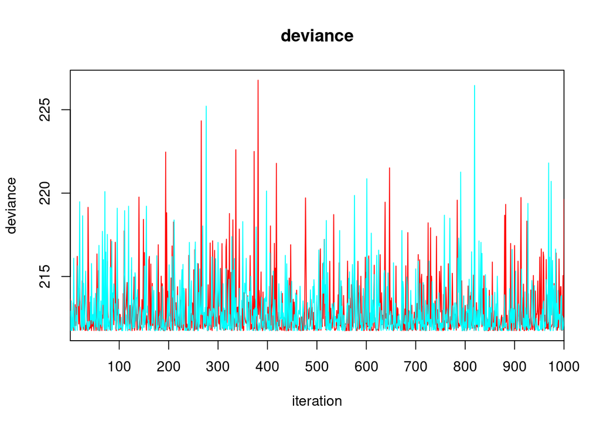

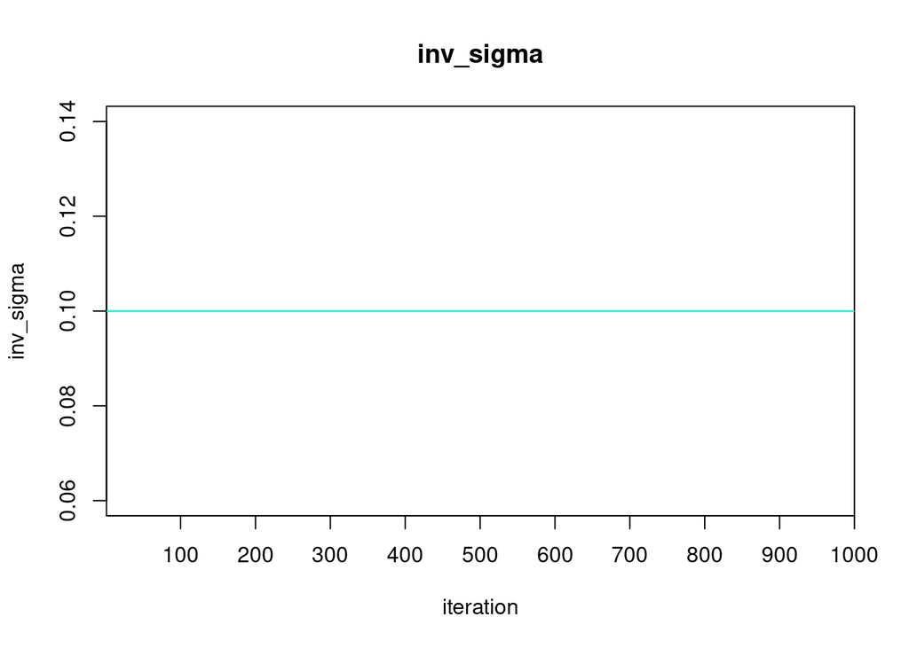

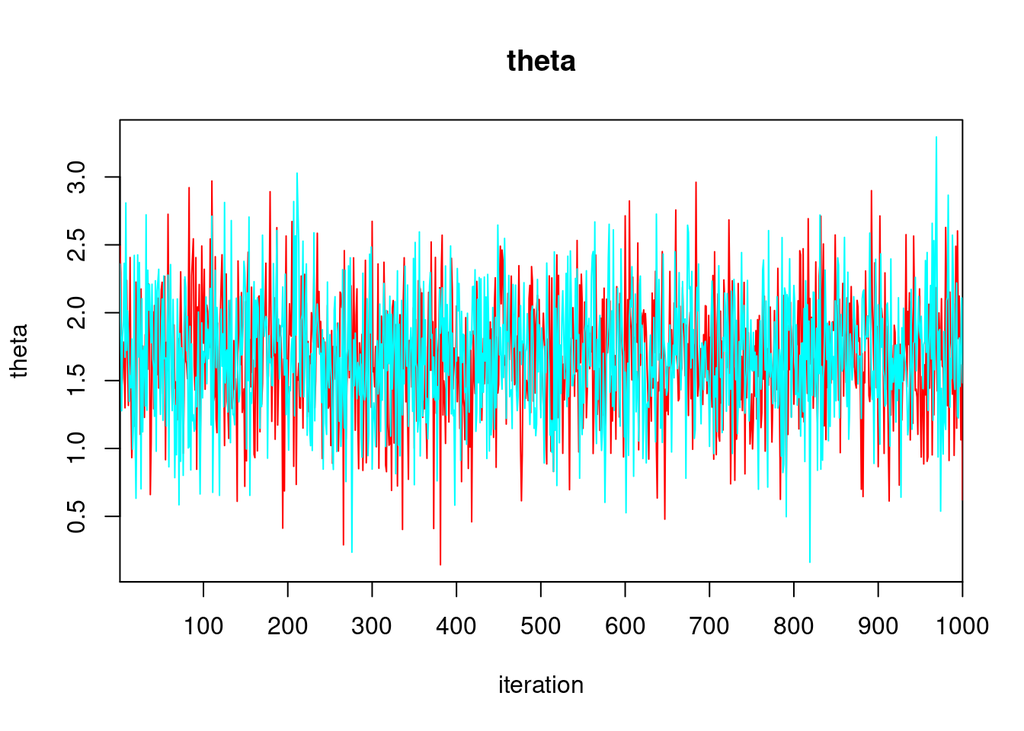

```r
traceplot(Mrun1)
```

**Question 1:** Changer le paramètre dans l’a priori et commenter le résultat obtenu. on utilisera par exemple: $\theta\sim \mathcal{N}(0,1/100)$ (attention: le paramètre dans dnorm correspond à l’inverse de l’écart-type).

**Question 2:** Changer le paramètre de variance afin que celui-ci suive une loi exponentielle: $\sigma^2 \sim \mathcal{E}(1)$

**Quelques distributions potentiellement utiles avec JAGS:**  
`dpois`, `dnorm`, `dt`,`dexp`,`dchisqr`,`dbin`,`ddexp`,`dbeta`

# 2 Estimateur du maximum de vraisemblance

**Exercice 1 (EMV):** Importer le data set `Survie.Rdata` contenant la dataframe `df3`. Ce sont des données de survie en nombre de jours pour des souris infectés par un virus et ayant subit un traitement antiviral.

```r
load(file='Survie.Rdata')
```

On modélise ces données par une loi $\Gamma(a,b)$ ($a$ et $b>0$) de densité:
$$f_{(a,b)}(x) =
\frac{b^a}{\Gamma(a)}x^{a-1}e^{-bx},\quad x>0.$$
Dans ce modèle la fonction de log-vraisemblance est:
$$\ell(a,b) = \sum_{i=1}^n\log f_{(a,b)}(x_i)=
na\log(b) -n\log(\Gamma(a)) +(a-1)\sum_{i=1}^n\log(x_i)
-b\sum_{i=1}^nx_i$$
Dans ce modèle, L’EMV n’a pas de forme explicite. On utilise l’algorithme de Newton-Raphson pour l’approcher. Soit $(a^{(t)},b^{(t)}),$ les valeurs des paramètres au temps $t.$ On a alors:
$$(a^{(t+1)},b^{(t+1)})^T =
(a^{(t)},b^{(t)})^T-[H(a^{(t)},b^{(t)})]^{-1}\nabla\ell(a^{(t)},b^{(t)})$$
Le gradient est:
$$\nabla\ell(a,b) = \left(\frac\partial{\partial a}
\ell(a,b),\frac\partial{\partial b} \ell(a,b)\right)^T
=\left(n\log b- n (\log\Gamma(a))'+\sum_{i=1}^n\log x_i,\quad
\frac{na}b-\sum_{i=1}^n x_i\right)^T$$
et le laplacien est:
$$[H(a,b)]^{-1}
=\left(\begin{array}{cc}
\frac{\partial^2}{\partial^2 a} \ell(a,b)&\frac{\partial^2}{\partial
a\partial b} \ell(a,b)\\
\frac{\partial^2}{\partial a\partial b}
\ell(a,b)&\frac{\partial^2}{\partial^2 b} \ell(a,b)
\end{array}\right)^{-1}
=
\frac1{n\left(1-a(\log\Gamma(a))''\right)}
\left(\begin{array}{cc}
a&b\\
b&b^2(\log\Gamma(a))''
\end{array}\right)$$

**1.** Ecrire une fonction qui met à jour les paramètres. Pour les dérivées de $\log\Gamma(a),$ on utilise les fonctions `digamma` et `trigamma`.

**2.** A l’aide d’une boucle while calculer un estimateur de l’EMV. Critère d’arrêt:
$$\left|\frac{\ell(a^{(t+1)},b^{(t+1)})-\ell(a^{(t)},b^{(t)})}{\ell(a^{(t+1)},b^{(t+1)})}\right|<\varepsilon,$$
avec $\varepsilon=1e-2.$ Initialiser les paramètres à l’aide des estimateurs de la méthode des moments (ou par une méthode simple de votre choix).

**3.** Estimer les paramètres à l’aide d’un modèle bayésien et du logiciel JAGS.

On fait comme précédemment : voici le modèle

```r
#Le modèle pour JAGS
model1 <- "
model{
for (i in 1:N) {
x[i] ~ dgamma(a, b)
}
a ~ dnorm(a_EMV, 1/10)
b ~ dnorm(b_EMV, 1/10)
}
"
```

Avec x[i] le temps de survie de la ieme souris

**4.** D’après vos résultats à la question précédente quelle est la probabilité que la survie moyenne soit inférieur à 20 jours ?

Le résultat cherché est donné par la fonction de distribution en x=20 de la loi gamma (a, b) avec a et b les paramètres obtenus à l’instant via jags.